# House Pricing Prediction

#### Group 11: Yazid Mouline & Guillaume Requena | AML Class 2020

```python
# imports
from google.colab import drive
from sklearn.linear_model import Lasso, Ridge, ElasticNet
from sklearn.model_selection import KFold, cross_val_score

import matplotlib.pyplot as plt
import matplotlib
import numpy as np
import pandas as pd
import seaborn as sns
import matplotlib.lines as mlines
```

### Introduction

The goal of this challenge is to predict the pricing of houses given a certain number of features. We decided quite promptly and intuitively to deal this problem as a regression problem since the target value is continuous (price of the houses).

This notebook aims to present concisely our process to deal with the dataset given, and to answer the problem: House Pricing Prediction. It presents our findings and results in three parts detailled in the following short summary. Each part will have a short introduction that will describe its content:

1. Data Preparation
2. Model Selection
3. Performance Evaluation

### Data Importation

```python
drive.mount('/content/drive/',force_remount=True)
```

```python
#original files
train = pd.read_csv('/content/drive/My Drive/AML/Chal1 - House/Data/train.csv')
test = pd.read_csv('/content/drive/My Drive/AML/Chal1 - House/Data/test.csv')
#modfied files after data preparation
X_train = pd.read_csv('/content/drive/My Drive/AML/Chal1 - House/Data/X_train.csv')
X_test = pd.read_csv('/content/drive/My Drive/AML/Chal1 - House/Data/X_test.csv')
y_train = pd.read_csv('/content/drive/My Drive/AML/Chal1 - House/Data/y_train.csv')
y_test = pd.read_csv('/content/drive/My Drive/AML/Chal1 - House/Data/y_test.csv')
perf = pd.read_csv('/content/drive/My Drive/AML/Chal1 - House/Data/perf_selection.csv')
model_tuned = pd.read_csv('/content/drive/My Drive/AML/Chal1 - House/Data/model_tuned.csv')
```

## 1. Data preparation

In order for the machine learning algorithms to be efficient we need to prepare the dataset. Here is how we processed:

**Data Cleaning:** First, the dataset needs to be cleaned: there are some NaN (missing) values that we have to deal with, and since we treat the problem as a regression problem, the categorical variables need to be converted into numerical variables.

**Data Visualization:** In this part, we analyze the dataset and show the interesting features, trends, correlations that we found. We show how this analysis helped us process the dataset and perform better.

**Data pre-processing:** Here, we show what were the biggest transformations we made to the dataset. Removing outliers, combining some features, normalization.

### 1.1. Data exploration

#### 1.1.1. Data cleaning

First, we dropped the column 'Id', it is useless since pandas has encoded indexing

##### Handling missing values

```python
train_na = (train.isnull().sum() / len(train)) * 100
train_na = train_na.drop(train_na[train_na == 0].index).sort_values(ascending=False)[:30]
missing_data = pd.DataFrame({'Table 1: Missing Ratio' :train_na})
missing_data.head(20)
```

|  | Table 1: Missing Ratio |
| --- | --- |
| PoolQC | 99.666667 |
| MiscFeature | 96.083333 |
| Alley | 93.750000 |
| Fence | 81.083333 |
| FireplaceQu | 47.000000 |
| LotFrontage | 17.500000 |
| GarageYrBlt | 5.583333 |
| GarageType | 5.583333 |
| GarageFinish | 5.583333 |
| GarageQual | 5.583333 |
| GarageCond | 5.583333 |
| BsmtExposure | 2.750000 |
| BsmtFinType2 | 2.750000 |
| BsmtFinType1 | 2.666667 |
| BsmtCond | 2.666667 |
| BsmtQual | 2.666667 |
| MasVnrArea | 0.500000 |
| MasVnrType | 0.500000 |

As we can see in the table 1, for some features, ratio of NaN values is ridiculous. These features are PoolQC, MiscFeature, Alley, Fence, FirePlaceQu. The easiest way to deal with these features could be to delete them all, however, we chose to keep these features instead of simply deleting them because we believe that they can sometimes have a real added value to the house.

'NA' attributes as described in the documentation have been misgiven for Nulls, we thus have to replace them accoridingly if it's a numerical feature or a categorical feature.

**Numerical features:**

There are three numerical features where there are NaN values in the train set(LotFrontage, GarageYrBlt, MasVnrArea). We deal with them in two different ways:

- *Replacing the NaN value with a 0:* Two of them are surfaces, so it makes sense to put a zero instead of a NaN.
- *Deleting the feature:* The feature GarageYrBlt is disturbing, it is a date, so replacing a NaN by a zero will be dangerous. We chose to delete this column. Plus, as we will see in the data visualization part it is very much correlated to the YearBuilt feature, so it doesn't add up much information.

However, we have to deal with all the features (pretending that we don't have access to the test set). For the numerical features, there should not be a problem. We'll replace all by 0 since they are all surfaces, or prices, except for MoSold, YrSold, YearBuilt and YearRemodAdd that should all be filled.

**Categorical features:**

- *Replacing the NaN values by an attribute 'NA':* For the categorical features, we only replaced all NaN values by a value 'NA' as intended in the original dataset.

##### Categorical features encoding

There is two main ways to deal with categorical features. Convert each feature into a numerical feature according to a given scale, or do a simple one hot encoding method.

The one hot encoding method allows to keep all the information of a given categorical feature, for a great price of added columns in the dataset. In order to limit greatly the number of added columns, we chose to replace a categorical feature by one numerical feature when it is possible. Meaning, when there is a coherent scale (Ex, Gd, TA, Fa, Po).

**Ordinal categorical features encoding:**

These are the features that have a certain order, a certain scale. For example, BsmtQual or BsmtExposure. With this method, we lost some information about each feature. Indeed, by choosing a linear scale, we consider that the two differences (Ex / Gd) and (Gd / TA) are equal, which is probably not be the case. Moreover, each feature can have its distribution, that we could analyze more accurately with the data visualization part.

We made this arbitrary choice for two main reasons:

- a linear scale seems quite fitting for most features, so we didn't falsify that much the information
- we greatly reduced the added number of columns: avoided the creation of 67 columns.

Finally, there are some scales where an attribute 'NA' was given. We could have chosen to start the scale at zero, giving no weight to a 'NA' attribute. Instead, we chose to apply an imputation algorithm, that replaces the 'NA' values by values that don't modify the global distribution. The algorithm used is MICE (Multivariate Imputation by Chained Equations).

**Nominal categorical features encoding:**

These are the features that don't seem to have an order, a scale. For instance, wheter there is no Alley, there is a Gravel Alley or a Paved Alley, we cannot really decide which is better than the other. Thus, we one-hot encoded all these variables.

#### 1.1.2. Data visualization

##### Sales Price analysis

The Sale Price mean is around 180 000`$` (assuming it's in the American market). Also, the minimum is 34 900`$` and the maximum 755 000`$` with a standard deviation of 81 000$ which is quite high. We can say then that the range of houses is large, and our dataset diverse.

As said in the descriptive notebook: "*The evaluation method for this challenge is the root mean squared error between the logarithm of the predicted value and the logarithm of the observed sales price. Taking logs ensures that errors in predicting expensive houses and cheap houses will have a similar impact on the overall result.*"

Indeed, the normal/Gaussian assumption is used because it is the most computationally convenient choice. This is a quadratic minimization problem (we use the RMSE as a metric) and can be solved using pure linear algebra. It this case, normality is then a good assumption because it provides us good properties that will probably work well for regression.

However, it has its drawbacks compared to other distributions. It is very sesnsitive to outliers, we'll have to be careful to remove them, in order to not distort our model.

Let's look at the Sale Price distribution, and the log(Sale Price) Distribution.

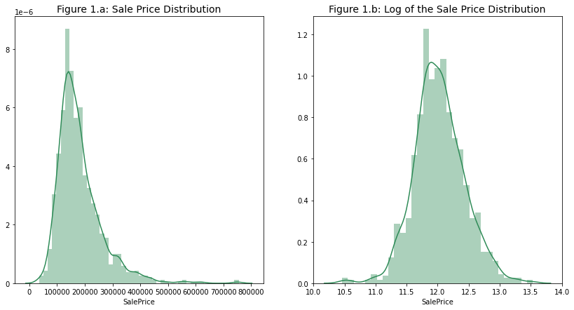

```python
fig = plt.figure(figsize=(14,7))
plt.subplot(1,2,1)
plt.title('Figure 1.a: Sale Price Distribution', fontsize=14)
sns.distplot(train['SalePrice'], color='seagreen')
plt.subplot(1,2,2)
plt.title('Figure 1.b: Log of the Sale Price Distribution', fontsize=14)
sns.distplot(np.log(train['SalePrice']), color='seagreen')
plt.show()
```

As said before, we can notice that the Sale Price distribution's deviates a bit from a normal distribution. Taking the log gives us a curve that is much more similar to a normal distribution.

That is why we made the choice to take the log of our target value.

##### Correlations between features

We first started by plotting the heatmap: correlation matrix between all the features. It gave us a gobal overview of our dataset. It allowed us to give more meaning to the features. It made sense that some features were correlated (GarageYrBlt and YearBuilt, or GrLivArea and TotRmsAbvGrd). It indicated us towards, box plots and scatter plots that we will show.

[figure not shown]

```python
fig = plt.figure(figsize=(12,12))

plt.subplot(2,2,1)
plt.title('Figure 2: YearBuilt with respect to GarageYrBlt', fontsize=10)
plt.xlabel('GarageYrBlt')
plt.ylabel('YearBuilt')
plt.scatter(train['YearBuilt'], train['GarageYrBlt'], color='seagreen', marker='.')

plt.subplot(2,2,2)
plt.title('Figure 3: GarageArea with respect to  GarageCars', fontsize=10)
sns.boxplot(train['GarageCars'], train['GarageArea'],palette=sns.cubehelix_palette(5, start=1.5, reverse=True))

plt.subplot(2,2,3)
plt.title('Figure 4: YearBuilt with respect to  GrLivArea', fontsize=10)
plt.xlabel('GrLivArea')
plt.ylabel('YearBuilt')
plt.scatter(train['GrLivArea'], train['YearBuilt'], color='seagreen', marker='.')

plt.subplot(2,2,4)
plt.title('Figure 5: YearBuilt with respect to  TotRmsAbvGrd', fontsize=10)
sns.boxplot(train['TotRmsAbvGrd'], train['GrLivArea'],palette=sns.cubehelix_palette(14, start=1.5, reverse=True))
plt.show()
```

The figures 2 to 5 are some of the interesting plots that we picked up. Some of the features are strongly correlated.

**Figure 2:** It was pertinent to drop the column GarageYrBlt in the DataCleaning part. Moreover, about this plot, it is interesting to note that it forms a line looking like a border. This makes total sense a Garage is often built after the house, or at the same time. There are other similar plots.

**Figure 3:** GarageArea and GarageCars are two features strongly correlated, this boxplot show that one is almost porportional to the other. This makes sense since two garage of the same size often fit a same number of cars. We could have chosen to drop one of the two features, but it seems useless to aim for that level of complexity.

**Figure 4:** As we will see in the next part, YearBuilt and GrLivArea are two features strongly correlated to SalePrice, meaning that they will probably have a high importance in the prediction, however between them they are not correlated at all.

**Figure 5:** Same as for figure 3, GrLivArea and TotRmsAbvGrd are strongly correlated, it makes sense, since a given living area is very proportional to the number of rooms of a house.

##### Correlations of other features to SalePrice

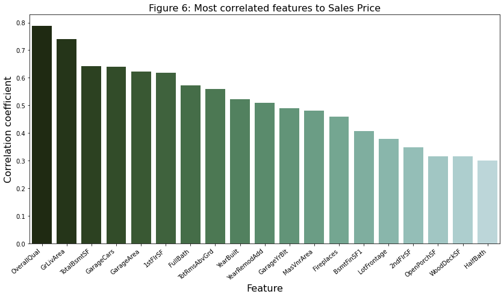

```python
corr_price = train.corr(method="pearson").abs()
corr_price_hist = corr_price['SalePrice'].sort_values(ascending=False)[1:20]

fig, ax = plt.subplots(figsize=(14,7))
ax = sns.barplot(x=corr_price_hist.index, y=corr_price_hist.values, palette=sns.cubehelix_palette(20, start=1.5, reverse=True))
ax.set_xticklabels(ax.get_xticklabels(), rotation=40, ha="right")

plt.xlabel('Feature', fontsize= 16)
plt.ylabel('Correlation coefficient', fontsize= 16)
plt.title('Figure 6: Most correlated features to Sales Price', fontsize=16)
plt.show()
```

- The feature OverallQual has the highest correlation coefficient to SalePrice, it seems fair but it is also somehow disturbing. We have no idea on how this feature is computed, especially since we have a very wide range of houses. Ex: Would a very large house with a pool, but a bit deteriorated (low OverallQual) be less expensive than a small brand new house ?
- It is very reassuring that the Price is close to porportional with GrLivArea, TotalBsmtSF and FullBath for example.
- In real life and according to real estate agents, location is the most important factor for a price's house. However, in this dataset, the only feature related to location is Neighborhood and it doesn't seem to be much correlated to the Sale Price.

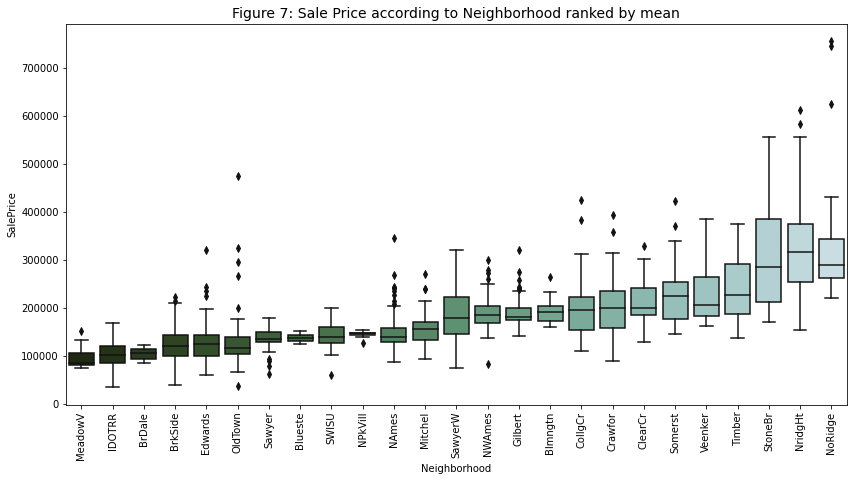

```python
f, ax = plt.subplots(figsize=(14, 7))
plt.title('Figure 7: Sale Price according to Neighborhood ranked by mean', fontsize=14)
fig = sns.boxplot(train['Neighborhood'], train['SalePrice'],
                  order=train.groupby('Neighborhood').mean()["SalePrice"].sort_values(ascending=True).index,
                  palette=sns.cubehelix_palette(25, start=1.5, reverse=True))
plt.xticks(rotation=90)
plt.show()
```

As we said righ before, location is important in real estate. The boxplot in figure 7 shows the Sale Price according to the Neighborhood. We can clearly see that there are rich neighborhoods and poor neighborhoods. It seems appropriate, in order to give more importance to this feature, to "bin" neighborhoods. Since, the demarcation is not clear in the middle, we only created two features RichNeighborhood and PoorNeighborhood that both have 2 values:

- 1 for the three richest or poorest neighborhoods
- 0 for the others

[figure not shown]

```python
plt.figure(figsize=(14,7))

plt.subplot(1,2,1)
plt.title('Figure 8.a: GarageQual with respect to Sale Price', fontsize=14)
sns.boxplot(train['HeatingQC'], train['SalePrice'],
            order=['Po','Fa','TA','Gd','Ex'],
            palette=sns.cubehelix_palette(5, start=1.5, reverse=True))

plt.subplot(1,2,2)
plt.title('Figure 8.b: ExterCond with respect to Sale Price', fontsize=14)
sns.boxplot(train['ExterCond'], train['SalePrice'],
            order=['Po','Fa','TA','Gd','Ex'],
            palette=sns.cubehelix_palette(5, start=1.5, reverse=True))
plt.show()
```

The two boxplots in figure 8 are of two categorical variables with respect to Sale Price, that we transformed into a numerical variable. For HeatingQC, we can see that choosing a linear scale was very relevant. In the case of ExterCond, it seems much less relevant, the mean of TA is higher than Gd or Ex. It seems fair, since the Exterior Condition can be fair but still have a nice house. We can hope that this compensates with other features.

##### Detecting outliers manually

By plotting, the scatter and boxplots of the features most correlated with SalePrice, we noticed that there were some obvious outliers that could falsify our dataset. However, we felt that these houses could be unique and we could not evaluate properly the tens of features in order to classify these houses as outliers. However, we used later on an Isolation Forest algorithm in order to detect anomalies automatically.

##### Data Visualization conclusion

The data visualization part allowed us to get a global understanding over the dataset. In addition to understanding general trends, grasping the most important, and less important features, how they relate to each other and to the target value; here are some major conclusions:

- the target value 'SalePrice' needs to be converted into 'logSalePrice'
- some features are strongly correlated between them, because they deal with the same global attribute (Garage for example) but we choose to keep them all because the dataset is not that big and we try to avoid losing information
- some features are strongly correlated to the 'SalePrice' feature and are a bit cheated('OverallQual')
- location is supposed to be a very important factor for realtors, but this dataset doesn't give much about it, we chose to add two features (RichNeighborhood and PoorNeighborhood)
- we detected some outliers manually , but we decided to use a more sophisticated model to drop an outlier

### 1.2. Data pre-processing

After cleaning and visualizing the dataset, here is what we did:

- We took the log of SalePrice (described why in the Data Visualization part).
- We didn't normalize nor standardize the data. One could argue that data needs to be normalized, however for our case, normalization gave worse results than without normalization in the beginning. We chose then to not normalize nor standardize.
- We created two new features, RichNeighborhood and PoorNeighborhood/
- We removed outliers we detected manually.
- To ensure that we remove all potential outliers, we used a more sophisticated technique that detects anomalies in the dataset dristribution. It is an Isolation Forest, that works similarly to a Random Forest but its aim is to detect anomalies in the multivariate distribution

Here are the dataframes' shapes before and after data preparation:

- train set (1200, 81)
- X_train (1187, 248) and y_train (1187, 1)
- test set (200, 81)
- X_test (200, 248) and y_test (200, 1)

One could argue that we have too many features and could use some feature elimination and feature reduction. But it seems that except for some very important features, the information about the price is well spread on all features. Also, we decided to use linear regression models with regularization (Lasso and Ridge) later on which are models that deal well with high dimensionality.

## 2. Model Selection

In this part, we describe our process to select a model. There is a first part (Models Selection) where we select different type of models, linear regression (with regularization) or RandomForestRegressor to cite a few.

We based our selection on two metrics: the RMSE (**Root Mean Squared Error**) between log(SalePrice) and log(SalePricePredicted), and the **coefficient of determination** R²

### 2.1 Models Testing

Firstly, we decided to try a few models and have a look on how well they perform on the training dataset. In oder to do that, we use a cross-validation strategy to validate more accurately our models. Using KFold and shuffling(cross-validation) and using cross_val_score with the right scoring.

```python
#Validation function
def rmse_cv(model, X, y):
    kf = KFold(shuffle=True, random_state=42).get_n_splits(X)
    rmse = -cross_val_score(model, X, y, scoring="neg_root_mean_squared_error", cv = kf)
    return(rmse)
```

```python
perf.drop(['Unnamed: 0'], axis=1)
```

|  | Model | RMSE | R2 | Running time (s) |
| --- | --- | --- | --- | --- |
| 0 | Linear Regression | 0.067793 | 0.932378 | 0.039515 |
| 1 | Ridge | 0.096517 | 0.950915 | 0.015266 |
| 2 | Lasso | 0.090459 | 0.934599 | 0.179645 |
| 3 | Random Forest Regressor | 0.142591 | 0.980493 | 2.772688 |
| 4 | XGBoost | 0.135376 | 0.960565 | 0.781729 |

We can notice that amongst all the models we tried, that we have really good results using an Ordinary Least Squares Linear Regression and it is not time consuming at all.

While RandomForest Regressor and XGBoost are not really worth it here.

A linear model seems very adapted to this problem.

Then we will keep working on a linear model and will try to regularize it using Lasso, Ridge and Elastic and hypertune these three models. They are all derived from the the OLS Linear Regression, only having an added L1 or L2 penalty or a convex combination of both. We will then select the best model.

However we have to keep in mind that overfitting can occur, especially since our training dataset is small, so we need to be careful with our parameters, and not select an alpha parameter with 10 significant figures.

### 2.2. Hypertuning LASSO / Ridge / ElasticNet

Using GridSearch we managed to optimize the alpha parameter. We tried to find the value for alpha that minimizes the RMSE.

We also used ElasticNet and optimized according to two parameters:

- alpha which is the penalty coefficient same as for Ridge and Lasso
- l1 ratio that gives a certain importance to the Lasso or Ridge penalty term

```python
alpha_lasso = [0.00005, 0.0001, 0.0002, 0.0003, 0.0004, 0.001, 0.003, 0.01, 0.1, 1]
cv_lasso = [rmse_cv(Lasso(alpha = alpha), X_train, y_train).mean() for alpha in alpha_lasso]
print(alpha_lasso[np.argmin(cv_lasso)])
cv_lasso = pd.Series(cv_lasso, index = alpha_lasso)
```

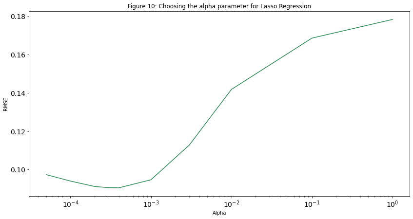

```python
plt.figure(figsize=(14,7))
cv_lasso.plot(title = "Figure 10: Choosing the alpha parameter for Lasso Regression", color='seagreen', fontsize=14)
plt.xlabel("Alpha")
plt.ylabel("RMSE")
plt.xscale('log')
plt.show()
```

These must be the best values for alpha for each algorithm in order to avoid both the overfitting and the underfitting, and to perform well.

```python
model_tuned.drop(['Unnamed: 0'], axis=1).iloc[['0','2','4']]
```

|  | Metric | Linear Regression | Lasso | Ridge | ElasticNet |
| --- | --- | --- | --- | --- | --- |
| 0 | R2_train | 0.971756 | 0.966089 | 0.971395 | 0.962270 |
| 2 | RMSE_train | 0.099399 | 0.088286 | 0.096678 | 0.090956 |
| 4 | Running time (s) | 0.033440 | 2.358953 | 0.009800 | 2.474352 |

Surprisingly, the running time is way higher for Lasso and ElasticNet, that is because our hypertuning chose a model with low alphas, it thus takes more time to converge.

## 3. Model Performance

We will see how the hypertuned LASSO model perform on the testing set.

Here is the final model we will use:

*Lasso(alpha=0.00038, copy_X=True, fit_intercept=True, max_iter=10000, normalize=False, positive=False, precompute=False, random_state=None, selection='cyclic', tol=0.0001, warm_start=False)*

```python
best_lasso = Lasso(alpha=0.00038,
                   copy_X=True,
                   fit_intercept=True,
                   max_iter=10000,
                   normalize=False,
                   positive=False,
                   precompute=False,
                   random_state=None,
                   selection='cyclic',
                   tol=0.0001,
                   warm_start=False).fit(X_train, y_train)
```

Our LASSO model picked 103 variables and eliminated the other 145 variables.

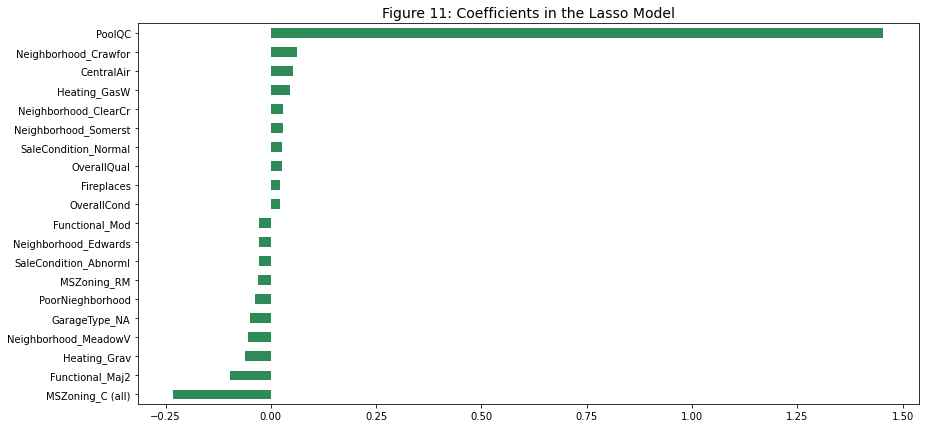

```python
coef = pd.Series(best_lasso.coef_, index = X_train.columns)

imp_coef = pd.concat([coef.sort_values().head(10), coef.sort_values().tail(10)])

plt.figure(figsize=(14,7))
matplotlib.rcParams['figure.figsize'] = (8.0, 10.0)
imp_coef.plot(kind = "barh", color='seagreen')
plt.title("Figure 11: Coefficients in the Lasso Model", fontsize=14)
plt.show()
```

We could have expected that the most important feature could be LotArea but in fact the most important is the PoolQC (PoolQuality). Probably it can come from the idea that the house price is implicitly linked to a category of house that have room for a pool. If you have room for a pool it means that the house is surely a good one. We can also notice that the OverallCond and the OverallQual are important features here which is not surprising.

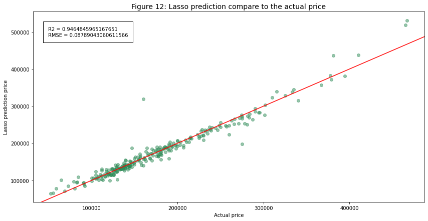

```python
from matplotlib.offsetbox import AnchoredText
lasso_preds_best = best_lasso.predict(X_test)

fig, ax = plt.subplots(figsize=(14, 7))
xplot_lasso_best = np.exp(y_test.to_numpy())
yplot_lasso_best = np.exp(lasso_preds_best)

r2=model_tuned[model_tuned['Metric']=='R2_test']['Lasso'].to_list()[0]
rmse=model_tuned[model_tuned['Metric']=='RMSE_test']['Lasso'].to_list()[0]

plt.xlabel('Actual price')
plt.ylabel('Lasso prediction price')
plt.title('Figure 12: Lasso prediction compare to the actual price', fontsize=14)
anchored_text = AnchoredText("R2 = {r2}\nRMSE = {rmse}".format(r2=r2, rmse=rmse), loc='upper left', pad=1, borderpad=2)
ax.add_artist(anchored_text)

ax.scatter(xplot_lasso_best, yplot_lasso_best, alpha=0.5, color='seagreen')
line = mlines.Line2D(ax.get_xlim(), ax.get_xlim(), color='red')
ax.add_line(line)
plt.show()
```

In average the predicted price is 5.646837259094008% wrong.

Up above we can notice that one value is particularly wrong (the one on the upper left). We came back on the test set to have a look at this line. We realized that the house has a LotArea 63887.0 ft<sup>2</sup> (=5935,29652 m<sup>2</sup>) and a OverallQual = 10 , and a Pool, which means it is very excellent. However the house has a surprising really low price 160000.0 $. The only reason is that it could be a house in the middle of nowhere with a huge field.

```python
model_tuned = model_tuned.drop(['Unnamed: 0'], axis=1)
```

```python
model_tuned[['Metric', 'Lasso']].iloc[['1','3','4']]
```

|  | Metric | Lasso |
| --- | --- | --- |
| 1 | R2_test | 0.946485 |
| 3 | RMSE_test | 0.087890 |
| 4 | Running time (s) | 2.358953 |

We obtain on the testing set, a quite low RMSE (0.088) compared to actual log values around 12. Also, the R2 is not the best, but still a regression model fitting at 0.95, means that (as we can see in Figure 12) our "line fits well most of the data". The surprising low price house causes some issue as well.

Also, our RMSE is a bit lower than for the cross-validation but our R² as well, we can say that the model is neither underfitting nor overfitting.

## Conclusion

To conclude, we chose a model that is easy to understand, and performs well. A **Linear Regression using Lasso Regularization** for three main reasons:

- Simplicity
- Good performance
- Dealing easily with high dimensionality

Surely, it is not perfect, especially when the actual prices start getting high, our model tends to overestimate the prices.

However, the dataset is very small, we could argue that with more data our model would be better trained.

Also, it is very interesting to see that our model predicts the Sale Price with a price range of 5%, which is lower than the realtor agents negotiation range.